# Tugas Individu Analisis Regresi

##Eksplorasi Normalitas Sisaan – qq-plot

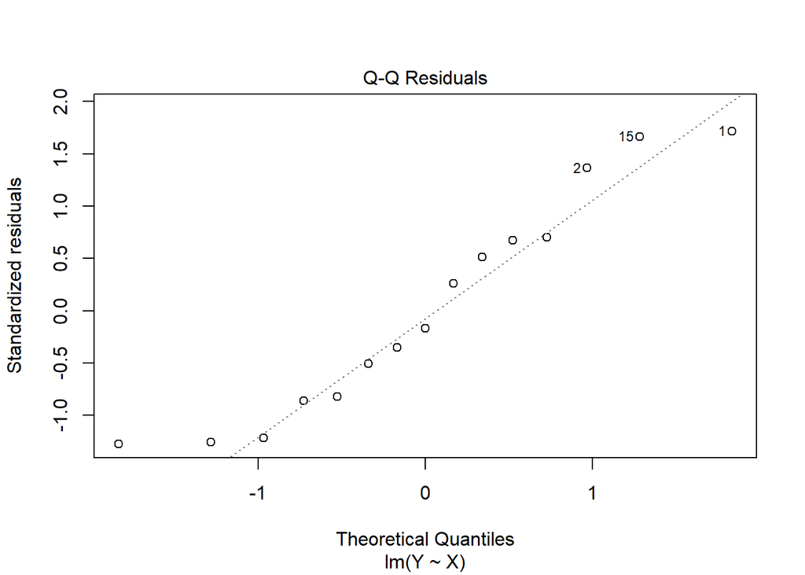

```r
plot(model.reg,2)
```

Dari qq-plot di atas dapat dilihat bahwa sisaan menyebar normal.

##Uji Formal Kondisi Gauss-Markov Pada uji formal asumsi ini, diharapkan nilai p-value > 0.05 dengan kesimpulan tak tolak $H_0$

##1. Nilai harapan sisaan sama dengan nol Hipotesis
$$H_0:\text{Nilai harapan sisaan sama dengan nol}\\H_1: \text{Nilai
harapan tidak sama dengan nol}$$

```r
t.test(model.reg$residuals,mu = 0,conf.level = 0.95)
```

```
##
##  One Sample t-test
##
## data:  model.reg$residuals
## t = -4.9493e-16, df = 14, p-value = 1
## alternative hypothesis: true mean is not equal to 0
## 95 percent confidence interval:
##  -3.143811  3.143811
## sample estimates:
##     mean of x
## -7.254614e-16
```

Dari uji t-test di atas didapatkan bahwa p-value > $\alpha$, maka pada taraf nyata 5% tak tolak $H_0$, artinya nilai harapan sisaan sama dengan nol.

##2. Ragam sisaan homogen Hipotesis
$$H_0:\text{Ragam sisaan homogen}\\H_1: \text{Ragam sisaan tidak homogen}$$

```r
bptest(model.reg)
```

```
##
##  studentized Breusch-Pagan test
##
## data:  model.reg
## BP = 0.52819, df = 1, p-value = 0.4674
```

Berdasarkan Breusch-Pagan test didapatkan bahwa nilai p-value > $\alpha$, maka pada taraf nyata 5% tak tolak $H_0$, artinya ragam sisaan homogen.

##3. Sisaan saling bebas Hipotesis
$$H_0:\text{Sisaan saling bebas}\\H_1: \text{Sisaan tidak saling bebas}$$

```r
dwtest(model.reg)
```

```
##
##  Durbin-Watson test
##
## data:  model.reg
## DW = 0.48462, p-value = 1.333e-05
## alternative hypothesis: true autocorrelation is greater than 0
```

##Uji Formal Normalitas Sisaan Hipotesis
$$H_0:\text{Sisaan menyebar normal}\\H_1: \text{Sisaan tidak menyebar
normal}$$

```r
sisaanmodel.reg <- resid(model.reg)
(normmodel.reg <- lillie.test(sisaanmodel.reg))
```

```
##
##  Lilliefors (Kolmogorov-Smirnov) normality test
##
## data:  sisaanmodel.reg
## D = 0.12432, p-value = 0.7701
```

Berdasarkan Lilliefors (Kolmogorov-Smirnov) normality test didapatkan bahwa p-value > $\alpha$, maka pada taraf nyata 5% tak tolak $H_0$, artinya sisaan menyebar normal.

Berdasarkan serangkaian pemeriksaan asumsi dan uji normalitas, didapatkan bahwa sisaan tidak saling bebas dan hal tersebut melanggar asumsi yang seharusnya sisaan saling bebas. Oleh karena itu perlu dilakukan transformasi agar asumsi tersebut dapat terpenuhi.

##Penanganan sisaan tidak saling bebas ##data transformasi

```r
sqrtY <- sqrt(data$Y)
sqrtX <- sqrt(data$X)
data2 <- data.frame(data$X, data$Y, sqrtY, sqrtX)
data2
```

```
##    data.X data.Y    sqrtY    sqrtX
## 1       2     54 7.348469 1.414214
## 2       5     50 7.071068 2.236068
## 3       7     45 6.708204 2.645751
## 4      10     37 6.082763 3.162278
## 5      14     35 5.916080 3.741657
## 6      19     25 5.000000 4.358899
## 7      26     20 4.472136 5.099020
## 8      31     16 4.000000 5.567764
## 9      34     18 4.242641 5.830952
## 10     38     13 3.605551 6.164414
## 11     45      8 2.828427 6.708204
## 12     52     11 3.316625 7.211103
## 13     53      8 2.828427 7.280110
## 14     60      4 2.000000 7.745967
## 15     65      6 2.449490 8.062258
```

##Transformasi Data

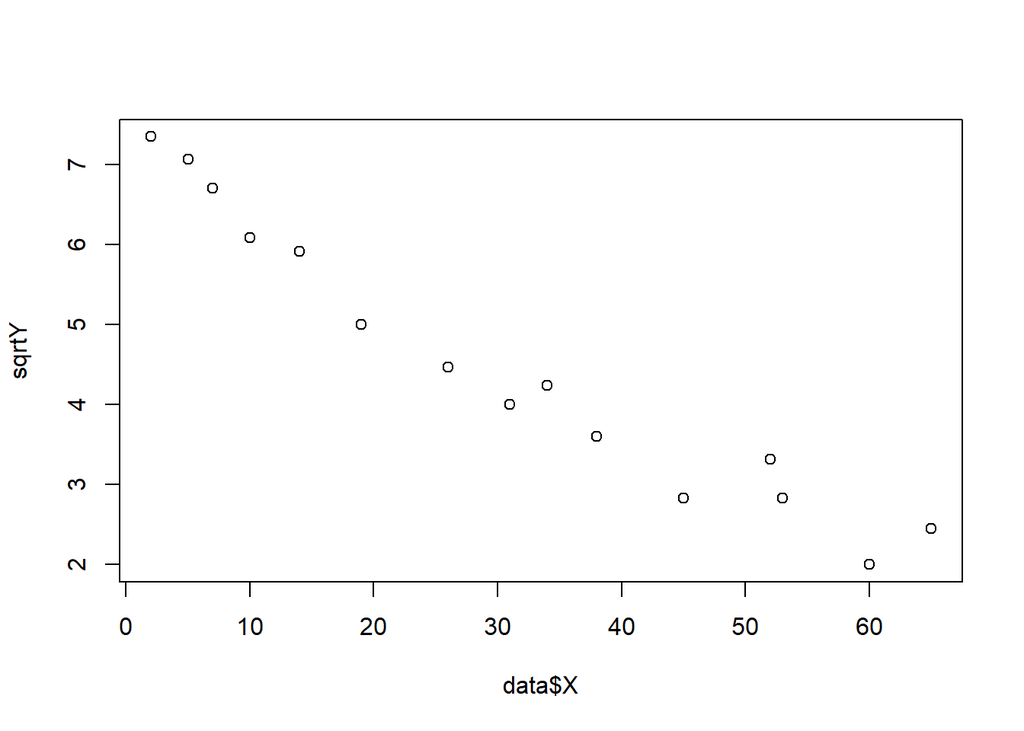

```r
plot(x = data$X,y = sqrtY)
```

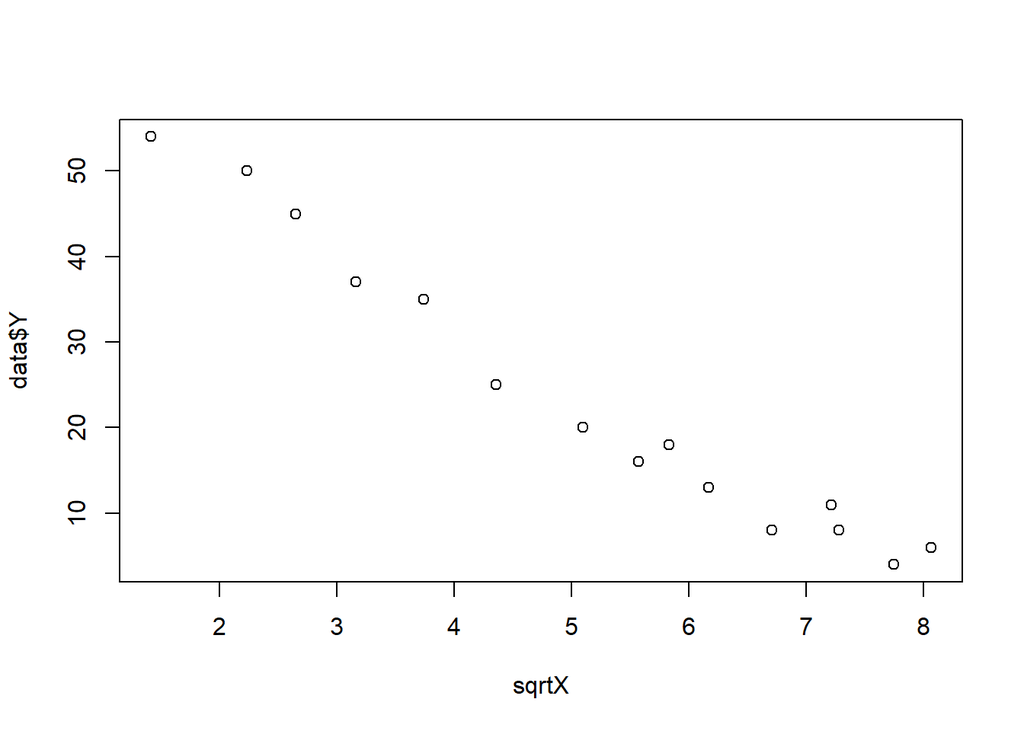

```r
plot(x = sqrtX,y = data$Y)
```

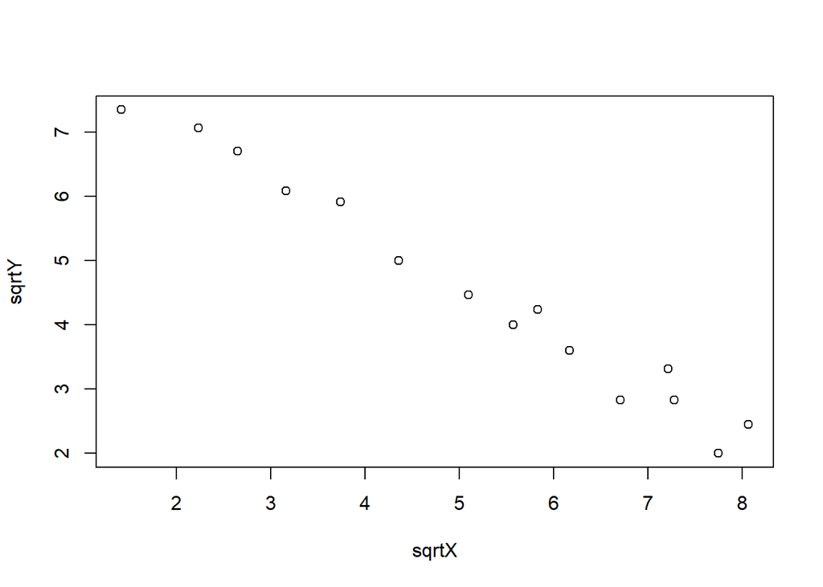

```r
plot(x = sqrtX,y = sqrtY)
```

```r
data.baru <- data.frame(sqrtX, sqrtY)
data.baru
```

```
##       sqrtX    sqrtY
## 1  1.414214 7.348469
## 2  2.236068 7.071068
## 3  2.645751 6.708204
## 4  3.162278 6.082763
## 5  3.741657 5.916080
## 6  4.358899 5.000000
## 7  5.099020 4.472136
## 8  5.567764 4.000000
## 9  5.830952 4.242641
## 10 6.164414 3.605551
## 11 6.708204 2.828427
## 12 7.211103 3.316625
## 13 7.280110 2.828427
## 14 7.745967 2.000000
## 15 8.062258 2.449490
```

##Model dan Pemeriksaan Asumsi sqrtX dengan Y

```r
model.reg1 = lm(formula = data$Y ~ sqrtX)
summary(model.reg1)
```

```
##
## Call:
## lm(formula = data$Y ~ sqrtX)
##
## Residuals:
##     Min      1Q  Median      3Q     Max
## -4.4518 -2.8559  0.7657  2.0035  5.2422
##
## Coefficients:
##             Estimate Std. Error t value Pr(>|t|)
## (Intercept)  63.2250     2.2712   27.84 5.67e-13 ***
## sqrtX        -7.7481     0.4097  -18.91 7.68e-11 ***
## ---
## Signif. codes:  0 '***' 0.001 '**' 0.01 '*' 0.05 '.' 0.1 ' ' 1
##
## Residual standard error: 3.262 on 13 degrees of freedom
## Multiple R-squared:  0.9649, Adjusted R-squared:  0.9622
## F-statistic: 357.7 on 1 and 13 DF,  p-value: 7.684e-11
```

Diperoleh model regresi berikut
$$\hat Y =
63.2250 - 7.7481X + e$$

```r
dwtest(model.reg1)
```

```
##
##  Durbin-Watson test
##
## data:  model.reg1
## DW = 1.1236, p-value = 0.01422
## alternative hypothesis: true autocorrelation is greater than 0
```

Berdasarkan Durbin-Witson test didapatkan p-value < $\alpha$, maka tolak $H_0$ pada taraf nyata 5% artinya sisaan tidak saling bebas sehingga asumsi tidak terpenuhi, bukan model terbaik.

X dengan sqrtY

```r
model.reg2 = lm(formula = sqrtY ~ data$X)
summary(model.reg2)
```

```
##
## Call:
## lm(formula = sqrtY ~ data$X)
##
## Residuals:
##      Min       1Q   Median       3Q      Max
## -0.53998 -0.38316 -0.01727  0.36045  0.70199
##
## Coefficients:
##              Estimate Std. Error t value Pr(>|t|)
## (Intercept)  7.015455   0.201677   34.79 3.24e-14 ***
## data$X      -0.081045   0.005477  -14.80 1.63e-09 ***
## ---
## Signif. codes:  0 '***' 0.001 '**' 0.01 '*' 0.05 '.' 0.1 ' ' 1
##
## Residual standard error: 0.4301 on 13 degrees of freedom
## Multiple R-squared:  0.9439, Adjusted R-squared:  0.9396
## F-statistic: 218.9 on 1 and 13 DF,  p-value: 1.634e-09
```

Diperoleh model regresi berikut
$$\hat Y =
7.015455 - 0.081045X + e$$

```r
dwtest(model.reg2)
```

```
##
##  Durbin-Watson test
##
## data:  model.reg2
## DW = 1.2206, p-value = 0.02493
## alternative hypothesis: true autocorrelation is greater than 0
```

Berdasarkan Durbin-Witson test didapatkan p-value < $\alpha$, maka tolak $H_0$ pada taraf nyata 5% artinya sisaan tidak saling bebas sehingga asumsi tidak terpenuhi, bukan model terbaik.

sqrtX dengan sqrtY

```r
model.reg3 = lm(formula = sqrtY ~ sqrtX)
summary(model.reg3)
```

```
##
## Call:
## lm(formula = sqrtY ~ sqrtX)
##
## Residuals:
##      Min       1Q   Median       3Q      Max
## -0.42765 -0.17534 -0.05753  0.21223  0.46960
##
## Coefficients:
##             Estimate Std. Error t value Pr(>|t|)
## (Intercept)  8.71245    0.19101   45.61 9.83e-16 ***
## sqrtX       -0.81339    0.03445  -23.61 4.64e-12 ***
## ---
## Signif. codes:  0 '***' 0.001 '**' 0.01 '*' 0.05 '.' 0.1 ' ' 1
##
## Residual standard error: 0.2743 on 13 degrees of freedom
## Multiple R-squared:  0.9772, Adjusted R-squared:  0.9755
## F-statistic: 557.3 on 1 and 13 DF,  p-value: 4.643e-12
```

Diperoleh model regresi berikut
$$\hat Y =
8.71245 - 0.81339X + e$$

```r
dwtest(model.reg3)
```

```
##
##  Durbin-Watson test
##
## data:  model.reg3
## DW = 2.6803, p-value = 0.8629
## alternative hypothesis: true autocorrelation is greater than 0
```

Berdasarkan Durbin-Witson test didapatkan p-value > $\alpha$, maka tak tolak $H_0$ pada taraf nyata 5% artinya sisaan saling bebas sehingga asumsi terpenuhi. Namun, perlu dilakukan pemeriksaan asumsi yang lain untuk memastikan bahwa model tersebut adalah model terbaik.

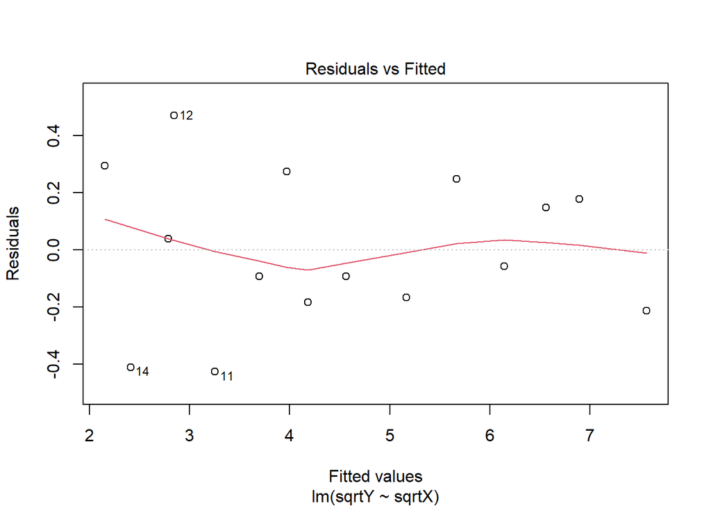

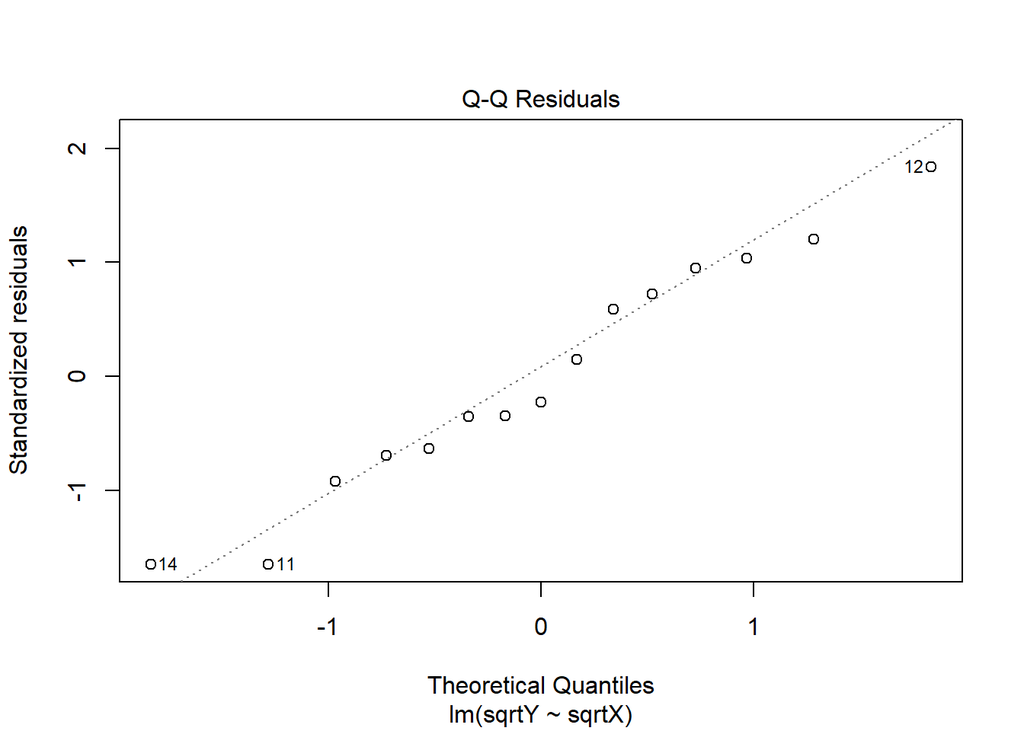

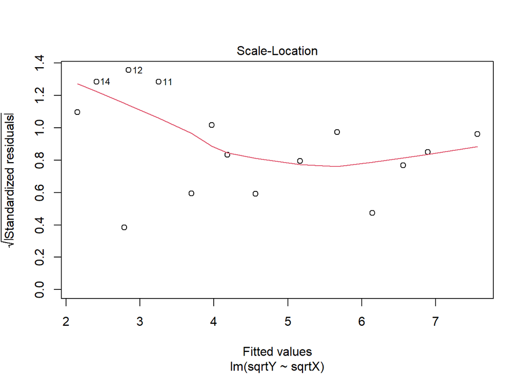

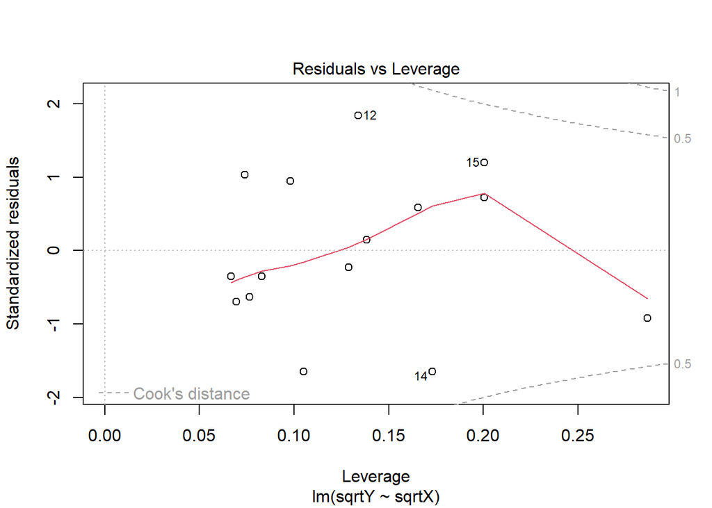

```r
plot(model.reg3)
```

##1. Nilai harapan sisaan sama dengan nol

```r
t.test(model.reg3$residuals,mu = 0,conf.level = 0.95)
```

```
##
##  One Sample t-test
##
## data:  model.reg3$residuals
## t = 2.0334e-16, df = 14, p-value = 1
## alternative hypothesis: true mean is not equal to 0
## 95 percent confidence interval:
##  -0.1463783  0.1463783
## sample estimates:
##    mean of x
## 1.387779e-17
```

```r
ncvTest(model.reg3)
```

```
## Non-constant Variance Score Test
## Variance formula: ~ fitted.values
## Chisquare = 2.160411, Df = 1, p = 0.14161
```

```r
sisaanmodel.reg3 <- resid(model.reg3)
(normmodel.reg3 <- lillie.test(sisaanmodel.reg3))
```

```
##
##  Lilliefors (Kolmogorov-Smirnov) normality test
##
## data:  sisaanmodel.reg3
## D = 0.11948, p-value = 0.817
```

Berdasarkan semua uji yang telah dilakukan p-value > $\alpha$ maka semua asumsi sudah terpenuhi pada taraf nyata 5%.

##Kesimpulan dan Transformasi Balik Oleh karena itu, didapatkan model terbaik dari hasil transformasi X dan Y menjadi $\sqrt X$ dan $\sqrt Y$ sehingga memenuhi asumsi dalam analisis regresi sederhana. Sehingga didapatkan model regresi berikut
$$\hat Y^{\frac{1}{2}} = 8.71245 -
0.81339X^{\frac{1}{2}} + e$$

Untuk mengembalikan model agar dapat menjelaskan peubah respons sebelum transformasi maka perlu dilakukan transformasi kembali. Langkah transformasi yaitu dengan mengkuadratkan kedua ruas sehingga didapatkan model terbaik sebagai berikut
$$\hat Y =
(8.71245 - 0.81339X^{\frac{1}{2}} + e)^2$$